# Exploratory Data Analysis and Basic Statistical Tests with Diamonds

Josh Valdeleon

2026-10-09

# 1 Learning Objectives

By the end of this demo, learners should be able to:

- Inspect and profile a dataset before analysis.
- Perform univariate, bivariate, and multivariate exploratory analysis.
- Visualize relationships between numerical and categorical variables.
- Formulate null and alternative hypotheses.
- Perform and interpret basic statistical tests.
- Distinguish statistical significance from practical significance.
- Recognize how confounding variables can affect conclusions.

# 2 Dataset

For this exercise, we will use the `diamonds` dataset included in `ggplot2`.

The dataset contains information about diamond prices and characteristics such as carat, cut, color, and clarity.

```r
data("diamonds", package = "ggplot2")

diamonds
```

```
## # A tibble: 53,940 × 10
##    carat cut       color clarity depth table price     x     y     z
##    <dbl> <ord>     <ord> <ord>   <dbl> <dbl> <int> <dbl> <dbl> <dbl>
##  1  0.23 Ideal     E     SI2      61.5    55   326  3.95  3.98  2.43
##  2  0.21 Premium   E     SI1      59.8    61   326  3.89  3.84  2.31
##  3  0.23 Good      E     VS1      56.9    65   327  4.05  4.07  2.31
##  4  0.29 Premium   I     VS2      62.4    58   334  4.2   4.23  2.63
##  5  0.31 Good      J     SI2      63.3    58   335  4.34  4.35  2.75
##  6  0.24 Very Good J     VVS2     62.8    57   336  3.94  3.96  2.48
##  7  0.24 Very Good I     VVS1     62.3    57   336  3.95  3.98  2.47
##  8  0.26 Very Good H     SI1      61.9    55   337  4.07  4.11  2.53
##  9  0.22 Fair      E     VS2      65.1    61   337  3.87  3.78  2.49
## 10  0.23 Very Good H     VS1      59.4    61   338  4     4.05  2.39
## # ℹ 53,930 more rows
```

# 3 1. Data Inspection

Before performing any analysis, inspect the structure of the dataset.

```r
glimpse(diamonds)
```

```
## Rows: 53,940
## Columns: 10
## $ carat   <dbl> 0.23, 0.21, 0.23, 0.29, 0.31, 0.24, 0.24, 0.26, 0.22, 0.23, 0.…
## $ cut     <ord> Ideal, Premium, Good, Premium, Good, Very Good, Very Good, Ver…
## $ color   <ord> E, E, E, I, J, J, I, H, E, H, J, J, F, J, E, E, I, J, J, J, I,…
## $ clarity <ord> SI2, SI1, VS1, VS2, SI2, VVS2, VVS1, SI1, VS2, VS1, SI1, VS1, …
## $ depth   <dbl> 61.5, 59.8, 56.9, 62.4, 63.3, 62.8, 62.3, 61.9, 65.1, 59.4, 64…
## $ table   <dbl> 55, 61, 65, 58, 58, 57, 57, 55, 61, 61, 55, 56, 61, 54, 62, 58…
## $ price   <int> 326, 326, 327, 334, 335, 336, 336, 337, 337, 338, 339, 340, 34…
## $ x       <dbl> 3.95, 3.89, 4.05, 4.20, 4.34, 3.94, 3.95, 4.07, 3.87, 4.00, 4.…
## $ y       <dbl> 3.98, 3.84, 4.07, 4.23, 4.35, 3.96, 3.98, 4.11, 3.78, 4.05, 4.…
## $ z       <dbl> 2.43, 2.31, 2.31, 2.63, 2.75, 2.48, 2.47, 2.53, 2.49, 2.39, 2.…
```

Check the dimensions.

```r
dim(diamonds)
```

```
## [1] 53940    10
```

View basic descriptive statistics.

```r
summary(diamonds)
```

```
##      carat               cut        color        clarity          depth
##  Min.   :0.2000   Fair     : 1610   D: 6775   SI1    :13065   Min.   :43.00
##  1st Qu.:0.4000   Good     : 4906   E: 9797   VS2    :12258   1st Qu.:61.00
##  Median :0.7000   Very Good:12082   F: 9542   SI2    : 9194   Median :61.80
##  Mean   :0.7979   Premium  :13791   G:11292   VS1    : 8171   Mean   :61.75
##  3rd Qu.:1.0400   Ideal    :21551   H: 8304   VVS2   : 5066   3rd Qu.:62.50
##  Max.   :5.0100                     I: 5422   VVS1   : 3655   Max.   :79.00
##                                     J: 2808   (Other): 2531
##      table           price             x                y
##  Min.   :43.00   Min.   :  326   Min.   : 0.000   Min.   : 0.000
##  1st Qu.:56.00   1st Qu.:  950   1st Qu.: 4.710   1st Qu.: 4.720
##  Median :57.00   Median : 2401   Median : 5.700   Median : 5.710
##  Mean   :57.46   Mean   : 3933   Mean   : 5.731   Mean   : 5.735
##  3rd Qu.:59.00   3rd Qu.: 5324   3rd Qu.: 6.540   3rd Qu.: 6.540
##  Max.   :95.00   Max.   :18823   Max.   :10.740   Max.   :58.900
##
##        z
##  Min.   : 0.000
##  1st Qu.: 2.910
##  Median : 3.530
##  Mean   : 3.539
##  3rd Qu.: 4.040
##  Max.   :31.800
##
```

Check for missing values.

```r
diamonds |>
  summarise(
    across(
      everything(),
      ~ sum(is.na(.))
    )
  )
```

```
## # A tibble: 1 × 10
##   carat   cut color clarity depth table price     x     y     z
##   <int> <int> <int>   <int> <int> <int> <int> <int> <int> <int>
## 1     0     0     0       0     0     0     0     0     0     0
```

# 4 2. Univariate Exploratory Analysis

## 4.1 2.1 Distribution of Diamond Price

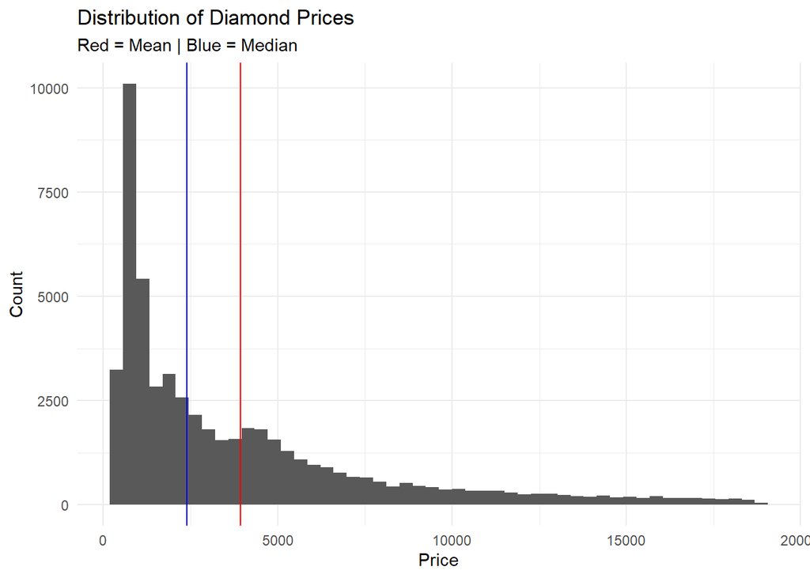

```r
mean_price <- mean(diamonds$price)
median_price <- median(diamonds$price)

diamonds |>
  ggplot(aes(x = price)) +
  geom_histogram(bins = 50) +
  geom_vline(xintercept = mean_price, color='red') +
  geom_vline(xintercept = median_price, color='blue') +
  labs(
    title = "Distribution of Diamond Prices",
    subtitle = "Red = Mean | Blue = Median",
    x = "Price",
    y = "Count"
  ) +
  theme_minimal()
```

Calculate descriptive statistics for price.

```r
diamonds |>
  summarise(
    n = n(),
    mean_price = mean(price),
    median_price = median(price),
    min_price = min(price),
    max_price = max(price),
    sd_price = sd(price)
  )
```

```
## # A tibble: 1 × 6
##       n mean_price median_price min_price max_price sd_price
##   <int>      <dbl>        <dbl>     <int>     <int>    <dbl>
## 1 53940      3933.         2401       326     18823    3989.
```

### 4.1.1 Discussion Questions

- Is the price distribution symmetric or skewed?
- Is the mean price higher or lower than the median?
- Are there possible outliers?

## 4.2 2.2 Distribution of Carat

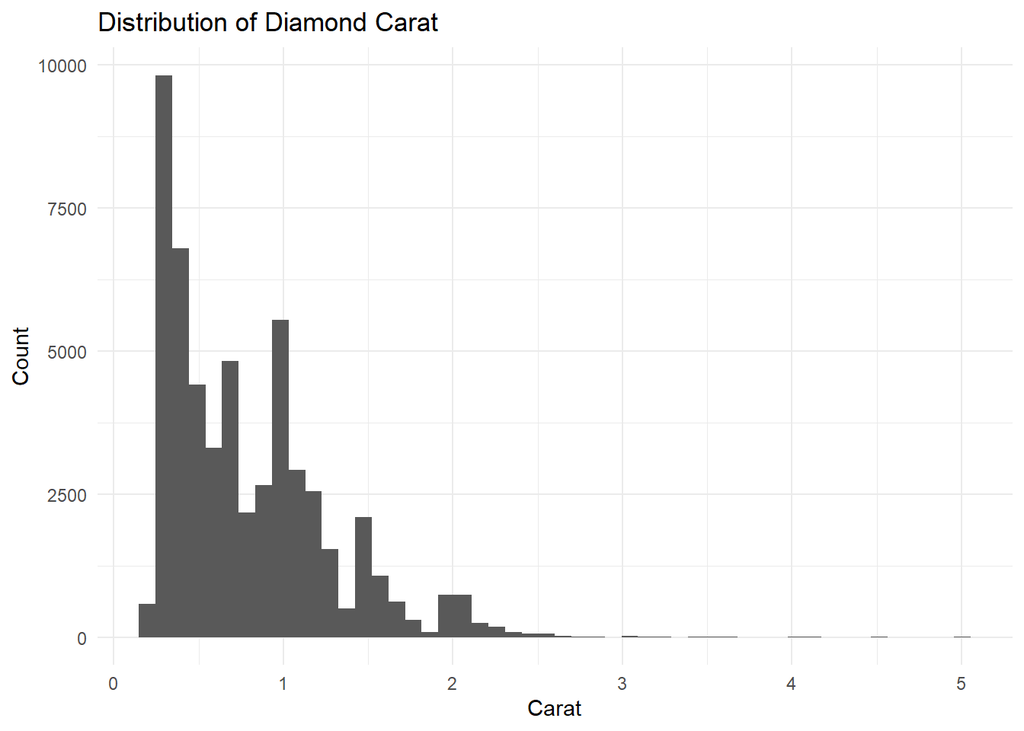

```r
diamonds |>
  ggplot(aes(x = carat)) +
  geom_histogram(bins = 50) +
  labs(
    title = "Distribution of Diamond Carat",
    x = "Carat",
    y = "Count"
  ) +
  theme_minimal()
```

## 4.3 2.3 Distribution of Diamond Cut

```r
diamonds |>
  count(cut) |>
  arrange(desc(n))
```

```
## # A tibble: 5 × 2
##   cut           n
##   <ord>     <int>
## 1 Ideal     21551
## 2 Premium   13791
## 3 Very Good 12082
## 4 Good       4906
## 5 Fair       1610
```

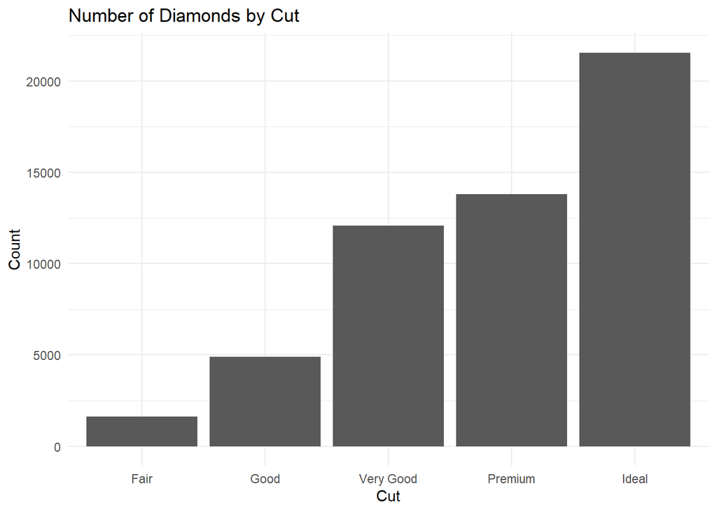

```r
diamonds |>
  ggplot(aes(x = cut)) +
  geom_bar() +
  labs(
    title = "Number of Diamonds by Cut",
    x = "Cut",
    y = "Count"
  ) +
  theme_minimal()
```

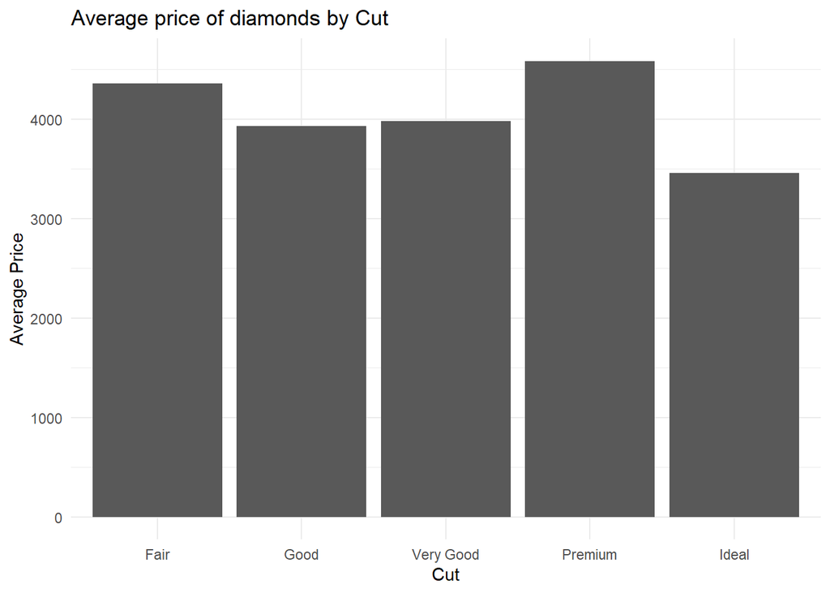

```r
diamonds |>
  ggplot(aes(x = cut, y = price)) +
  stat_summary(fun = mean, geom = 'bar') +
  labs(
    title = "Average price of diamonds by Cut",
    x = "Cut",
    y = "Average Price"
  ) +
  theme_minimal()
```

# 5 3. Bivariate Exploratory Analysis

## 5.1 3.1 Carat and Price

**Question:** Do larger diamonds tend to have higher prices?

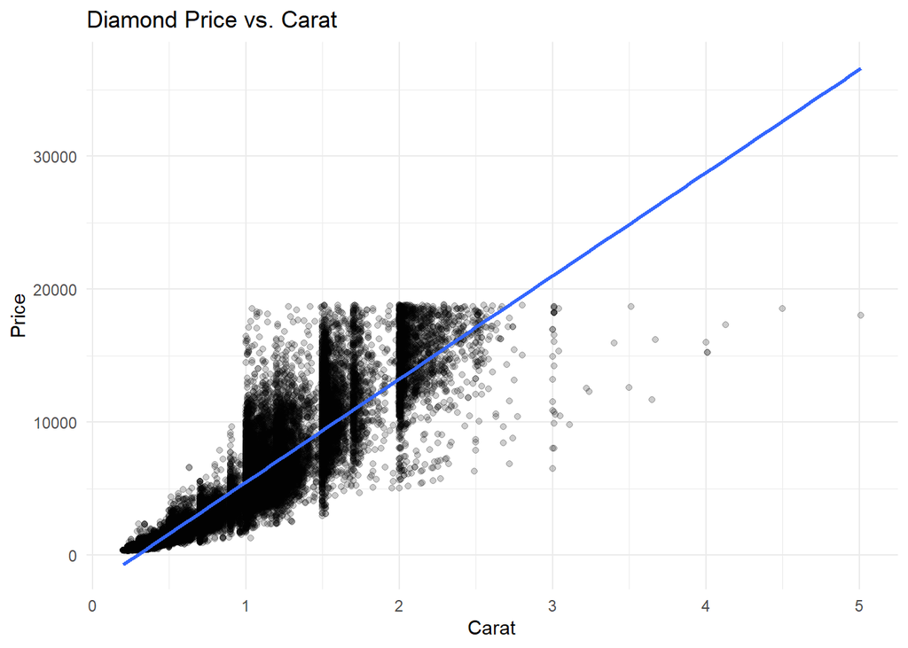

```r
diamonds |>
  ggplot(aes(x = carat, y = price)) +
  geom_point(alpha = 0.2) +
  geom_smooth(method = "lm") +
  labs(
    title = "Diamond Price vs. Carat",
    x = "Carat",
    y = "Price"
  ) +
  theme_minimal()
```

### 5.1.1 Discussion Questions

- What direction does the relationship appear to have?
- Does the relationship look linear?
- Does the variability in price change as carat increases?

## 5.2 3.2 Cut and Price

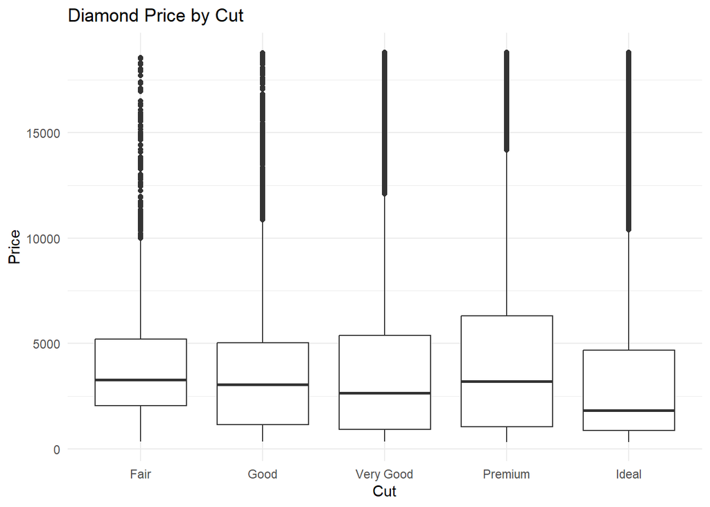

```r
diamonds |>
  ggplot(aes(x = cut, y = price)) +
  geom_boxplot() +
  labs(
    title = "Diamond Price by Cut",
    x = "Cut",
    y = "Price"
  ) +
  theme_minimal()
```

Summarize price by cut.

```r
diamonds |>
  group_by(cut) |>
  summarise(
    n = n(),
    mean_price = mean(price),
    median_price = median(price),
    mean_carat = mean(carat),
    .groups = "drop"
  )
```

```
## # A tibble: 5 × 5
##   cut           n mean_price median_price mean_carat
##   <ord>     <int>      <dbl>        <dbl>      <dbl>
## 1 Fair       1610      4359.        3282       1.05
## 2 Good       4906      3929.        3050.      0.849
## 3 Very Good 12082      3982.        2648       0.806
## 4 Premium   13791      4584.        3185       0.892
## 5 Ideal     21551      3458.        1810       0.703
```

### 5.2.1 Discussion Question

A higher-quality cut might be expected to have a higher price.

Does the raw data support that expectation?

# 6 4. Multivariate Exploratory Analysis

Explore the correlation matrix of all numeric variables.

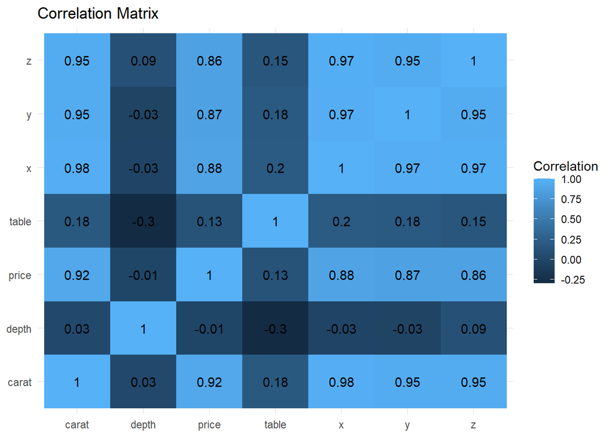

```r
cor_matrix <- diamonds |>
  select(where(is.numeric)) |>
  cor()

cor_df <- cor_matrix |>
  as.data.frame() |>
  rownames_to_column("variable1") |>
  pivot_longer(
    -variable1,
    names_to = "variable2",
    values_to = "correlation"
  )

cor_df |>
  ggplot(
    aes(
      x = variable1,
      y = variable2,
      fill = correlation
    )
  ) +
  geom_tile() +
  geom_text(
    aes(label = round(correlation, 2))
  ) +
  labs(
    title = "Correlation Matrix",
    x = NULL,
    y = NULL,
    fill = "Correlation"
  ) +
  theme_minimal()
```

Explore the relationship between carat and price while also considering diamond cut.

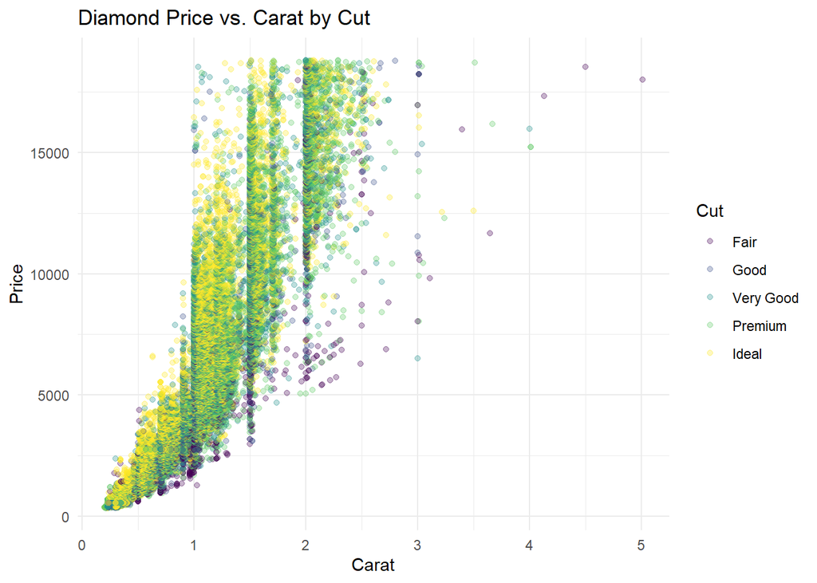

```r
diamonds |>
  ggplot(
    aes(
      x = carat,
      y = price,
      color = cut
    )
  ) +
  geom_point(alpha = 0.3) +
  labs(
    title = "Diamond Price vs. Carat by Cut",
    x = "Carat",
    y = "Price",
    color = "Cut"
  ) +
  theme_minimal()
```

This visualization illustrates why analysts should be cautious when interpreting relationships from only one or two variables.

```r
diamonds |>
  slice_sample(n = 3000) |>
  plot_ly(
    x = ~x,
    y = ~y,
    z = ~z,
    color = ~cut,
    size = ~price,
    type = "scatter3d",
    mode = "markers",
    marker = list(
      opacity = 0.5
    )
  ) |>
  layout(
    title = "Diamond Dimensions by Cut and Price",
    scene = list(
      xaxis = list(title = "Length (x)"),
      yaxis = list(title = "Width (y)"),
      zaxis = list(title = "Depth (z)")
    )
  )
```

[interactive chart not shown]

# 7 5. Statistical Test 1: Pearson Correlation

## 7.1 Research Question

**Is diamond carat significantly associated with diamond price?**

### 7.1.1 Hypotheses

- **H0:** There is no linear correlation between carat and price.
- **H1:** There is a linear correlation between carat and price.

First, calculate the correlation coefficient.

```r
cor(
  diamonds$carat,
  diamonds$price
)
```

```
## [1] 0.9215913
```

Perform a Pearson correlation test.

```r
cor.test(
  diamonds$carat,
  diamonds$price,
  method = "pearson"
)
```

```
##
##  Pearson's product-moment correlation
##
## data:  diamonds$carat and diamonds$price
## t = 551.41, df = 53938, p-value < 2.2e-16
## alternative hypothesis: true correlation is not equal to 0
## 95 percent confidence interval:
##  0.9203098 0.9228530
## sample estimates:
##       cor
## 0.9215913
```

### 7.1.2 Interpretation Guide

Focus on:

- correlation coefficient (`r`)
- direction of the relationship
- strength of the relationship
- p-value
- confidence interval

If the p-value is below the chosen significance level, such as 0.05, reject the null hypothesis.

However, remember:

> Statistical association does not automatically imply causation.

# 8 6. Statistical Test 2: Independent Samples t-test

## 8.1 Research Question

**Do Ideal-cut and Premium-cut diamonds have different average prices?**

Create a subset containing only the two groups.

```r
diamonds_two_cuts <- diamonds |>
  filter(cut %in% c("Ideal", "Premium"))

diamonds_two_cuts |>
  count(cut)
```

```
## # A tibble: 2 × 2
##   cut         n
##   <ord>   <int>
## 1 Premium 13791
## 2 Ideal   21551
```

Compare their descriptive statistics.

```r
diamonds_two_cuts |>
  group_by(cut) |>
  summarise(
    n = n(),
    mean_price = mean(price),
    median_price = median(price),
    sd_price = sd(price),
    .groups = "drop"
  )
```

```
## # A tibble: 2 × 5
##   cut         n mean_price median_price sd_price
##   <ord>   <int>      <dbl>        <int>    <dbl>
## 1 Premium 13791      4584.         3185    4349.
## 2 Ideal   21551      3458.         1810    3808.
```

### 8.1.1 Hypotheses

- **H0:** Mean price of Ideal diamonds = Mean price of Premium diamonds.
- **H1:** Mean price of Ideal diamonds != Mean price of Premium diamonds.

Perform the test.

```r
t.test(
  price ~ cut,
  data = diamonds_two_cuts
)
```

```
##
##  Welch Two Sample t-test
##
## data:  price by cut
## t = 24.918, df = 26552, p-value < 2.2e-16
## alternative hypothesis: true difference in means between group Premium and group Ideal is not equal to 0
## 95 percent confidence interval:
##  1038.088 1215.344
## sample estimates:
## mean in group Premium   mean in group Ideal
##              4584.258              3457.542
```

### 8.1.2 Interpretation Guide

If the p-value is below 0.05, there is evidence that the two groups have different mean prices.

Because the `diamonds` dataset is large, small differences can become statistically significant.

This means we should also ask:

> Is the difference large enough to matter in practice?

# 9 7. Statistical Test 3: One-Way ANOVA

## 9.1 Research Question

**Does average diamond price differ across cut categories?**

### 9.1.1 Hypotheses

- **H0:** All cut categories have the same population mean price.
- **H1:** At least one cut category has a different population mean price.

Fit the ANOVA model.

```r
price_cut_anova <- aov(
  price ~ cut,
  data = diamonds
)

summary(price_cut_anova)
```

```
##                Df    Sum Sq   Mean Sq F value Pr(>F)
## cut             4 1.104e+10 2.760e+09   175.7 <2e-16 ***
## Residuals   53935 8.474e+11 1.571e+07
## ---
## Signif. codes:  0 '***' 0.001 '**' 0.01 '*' 0.05 '.' 0.1 ' ' 1
```

### 9.1.2 Interpretation

A statistically significant ANOVA tells us that at least one group differs.

It does **not** tell us exactly which groups differ.

# 10 8. Post-Hoc Analysis: Tukey HSD

If the ANOVA is statistically significant, perform pairwise comparisons.

```r
TukeyHSD(price_cut_anova)
```

```
##   Tukey multiple comparisons of means
##     95% family-wise confidence level
##
## Fit: aov(formula = price ~ cut, data = diamonds)
##
## $cut
##                          diff         lwr        upr     p adj
## Good-Fair          -429.89331  -740.44880  -119.3378 0.0014980
## Very Good-Fair     -376.99787  -663.86215   -90.1336 0.0031094
## Premium-Fair        225.49994   -59.26664   510.2665 0.1950425
## Ideal-Fair         -901.21579 -1180.57139  -621.8602 0.0000000
## Very Good-Good       52.89544  -130.15186   235.9427 0.9341158
## Premium-Good        655.39325   475.65120   835.1353 0.0000000
## Ideal-Good         -471.32248  -642.36268  -300.2823 0.0000000
## Premium-Very Good   602.49781   467.76249   737.2331 0.0000000
## Ideal-Very Good    -524.21792  -647.10467  -401.3312 0.0000000
## Ideal-Premium     -1126.71573 -1244.62267 -1008.8088 0.0000000
```

### 10.0.1 Discussion Questions

- Which pairs of cut categories have statistically significant differences?
- Which comparisons show the largest differences?
- Are these differences necessarily caused by cut quality alone?

# 11 9. Statistical Test 4: Chi-Square Test of Independence

## 11.1 Research Question

**Is diamond cut associated with diamond color?**

Both variables are categorical.

Create a contingency table.

```r
cut_color_table <- table(
  diamonds$cut,
  diamonds$color
)

cut_color_table
```

```
##
##                D    E    F    G    H    I    J
##   Fair       163  224  312  314  303  175  119
##   Good       662  933  909  871  702  522  307
##   Very Good 1513 2400 2164 2299 1824 1204  678
##   Premium   1603 2337 2331 2924 2360 1428  808
##   Ideal     2834 3903 3826 4884 3115 2093  896
```

### 11.1.1 Hypotheses

- **H0:** Diamond cut and color are independent.
- **H1:** Diamond cut and color are associated.

Perform the chi-square test.

```r
chisq.test(cut_color_table)
```

```
##
##  Pearson's Chi-squared test
##
## data:  cut_color_table
## X-squared = 310.32, df = 24, p-value < 2.2e-16
```

Visualize the proportions.

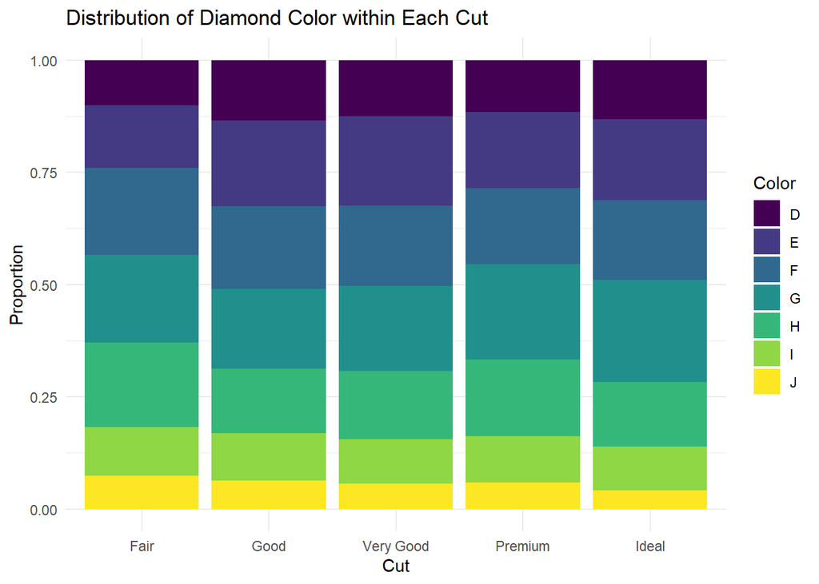

```r
diamonds |>
  ggplot(aes(x = cut, fill = color)) +
  geom_bar(position = "fill") +
  labs(
    title = "Distribution of Diamond Color within Each Cut",
    x = "Cut",
    y = "Proportion",
    fill = "Color"
  ) +
  theme_minimal()
```

### 11.1.2 Interpretation Guide

A statistically significant chi-square result suggests that cut and color are not independent.

However, statistical association does not by itself explain why the variables are related.

# 12 10. Investigating a Surprising Finding

Return to the earlier question:

> Do better-cut diamonds cost more?

Inspect the raw average price and carat by cut.

```r
diamonds |>
  group_by(cut) |>
  summarise(
    n = n(),
    mean_price = mean(price),
    median_price = median(price),
    mean_carat = mean(carat),
    .groups = "drop"
  )
```

```
## # A tibble: 5 × 5
##   cut           n mean_price median_price mean_carat
##   <ord>     <int>      <dbl>        <dbl>      <dbl>
## 1 Fair       1610      4359.        3282       1.05
## 2 Good       4906      3929.        3050.      0.849
## 3 Very Good 12082      3982.        2648       0.806
## 4 Premium   13791      4584.        3185       0.892
## 5 Ideal     21551      3458.        1810       0.703
```

The raw average prices may not follow the simple pattern we might initially expect.

Why?

One possible explanation is **carat**.

Diamond price is strongly related to diamond size, and the distribution of carat differs across cut categories.

# 13 11. Controlling for Carat with Regression

We can examine the relationship between cut and price while controlling for carat using a linear regression model.

```r
price_model <- lm(
  price ~ carat + cut,
  data = diamonds
)

summary(price_model)
```

```
##
## Call:
## lm(formula = price ~ carat + cut, data = diamonds)
##
## Residuals:
##      Min       1Q   Median       3Q      Max
## -17540.7   -791.6    -37.6    522.1  12721.4
##
## Coefficients:
##             Estimate Std. Error  t value Pr(>|t|)
## (Intercept) -2701.38      15.43 -175.061  < 2e-16 ***
## carat        7871.08      13.98  563.040  < 2e-16 ***
## cut.L        1239.80      26.10   47.502  < 2e-16 ***
## cut.Q        -528.60      23.13  -22.851  < 2e-16 ***
## cut.C         367.91      20.21   18.201  < 2e-16 ***
## cut^4          74.59      16.24    4.593 4.37e-06 ***
## ---
## Signif. codes:  0 '***' 0.001 '**' 0.01 '*' 0.05 '.' 0.1 ' ' 1
##
## Residual standard error: 1511 on 53934 degrees of freedom
## Multiple R-squared:  0.8565, Adjusted R-squared:  0.8565
## F-statistic: 6.437e+04 on 5 and 53934 DF,  p-value: < 2.2e-16
```

Compare this with a model using only cut.

```r
cut_only_model <- lm(
  price ~ cut,
  data = diamonds
)

summary(cut_only_model)
```

```
##
## Call:
## lm(formula = price ~ cut, data = diamonds)
##
## Residuals:
##    Min     1Q Median     3Q    Max
##  -4258  -2741  -1494   1360  15348
##
## Coefficients:
##             Estimate Std. Error t value Pr(>|t|)
## (Intercept)  4062.24      25.40 159.923  < 2e-16 ***
## cut.L        -362.73      68.04  -5.331  9.8e-08 ***
## cut.Q        -225.58      60.65  -3.719    2e-04 ***
## cut.C        -699.50      52.78 -13.253  < 2e-16 ***
## cut^4        -280.36      42.56  -6.588  4.5e-11 ***
## ---
## Signif. codes:  0 '***' 0.001 '**' 0.01 '*' 0.05 '.' 0.1 ' ' 1
##
## Residual standard error: 3964 on 53935 degrees of freedom
## Multiple R-squared:  0.01286,    Adjusted R-squared:  0.01279
## F-statistic: 175.7 on 4 and 53935 DF,  p-value: < 2.2e-16
```

### 13.0.1 Discussion Questions

- How does the interpretation of cut change after including carat?
- Why might the raw average price by cut be misleading?
- What other variables might affect diamond price?
- Does controlling for carat prove that cut causes changes in price?

# 14 12. Key Takeaways

Exploratory analysis and statistical testing answer related but different questions.

EDA helps us **discover patterns and generate questions**.

Statistical tests help us evaluate whether observed differences or relationships are likely to be consistent with a population-level relationship.

In this exercise, we used:

1. **Pearson correlation** for two numerical variables.
2. **Independent samples t-test** for comparing two groups.
3. **One-way ANOVA** for comparing more than two groups.
4. **Tukey HSD** for post-hoc comparisons.
5. **Chi-square test** for relationships between categorical variables.
6. **Linear regression** to examine relationships while considering another variable.

Most importantly:

> A statistically significant result is not automatically an important result, and an observed association does not automatically imply causation.

# 15 13. Challenge Questions

Try answering the following independently.

1. Is `depth` significantly correlated with `price`?
2. Do `Ideal` and `Premium` diamonds have different average carat sizes?
3. Does average carat differ across clarity categories?
4. Are diamond `cut` and `clarity` associated?
5. Does the relationship between carat and price differ across cut categories?
6. Build a regression model using `carat`, `cut`, `color`, and `clarity` to explain diamond price.